# Part I - Ford GoBike

## Introduction

> This data set includes information about individual rides made in a bike-sharing system covering the greater San Francisco Bay area

## Preliminary Wrangling

```python
# import all packages and set plots to be embedded inline
import numpy as np
import pandas as pd
import matplotlib.pyplot as plt
import seaborn as sb

%matplotlib inline
```

## Loading the dataset

```python
df= pd.read_csv('201902-fordgobike-tripdata.csv')
#the columns and rows of the dataset
print(df.shape)
print(df.columns)
print(df.dtypes)
```

```
(183412, 16)
Index(['duration_sec', 'start_time', 'end_time', 'start_station_id',
       'start_station_name', 'start_station_latitude',
       'start_station_longitude', 'end_station_id', 'end_station_name',
       'end_station_latitude', 'end_station_longitude', 'bike_id', 'user_type',
       'member_birth_year', 'member_gender', 'bike_share_for_all_trip'],
      dtype='object')
duration_sec                 int64
start_time                  object
end_time                    object
start_station_id           float64
start_station_name          object
start_station_latitude     float64
start_station_longitude    float64
end_station_id             float64
end_station_name            object
end_station_latitude       float64
end_station_longitude      float64
bike_id                      int64
user_type                   object
member_birth_year          float64
member_gender               object
bike_share_for_all_trip     object
dtype: object
```

```python
#null entries
df.isnull().sum()
```

```
duration_sec                  0
start_time                    0
end_time                      0
start_station_id            197
start_station_name          197
start_station_latitude        0
start_station_longitude       0
end_station_id              197
end_station_name            197
end_station_latitude          0
end_station_longitude         0
bike_id                       0
user_type                     0
member_birth_year          8265
member_gender              8265
bike_share_for_all_trip       0
dtype: int64
```

```python
df.duplicated().sum()
```

```
0
```

```python
df_clean= df.copy()

#change the start and end time to date time series
df_clean['start_time']=pd.to_datetime(df_clean['start_time'])
df_clean['end_time']= pd.to_datetime(df_clean['end_time'])
df_clean['end_time'].dtypes
df_clean['start_time'].dtypes
```

```
dtype('<M8[ns]')
```

```python
df_clean.describe()
```

|  | duration_sec | start_station_id | start_station_latitude | start_station_longitude | end_station_id | end_station_latitude | end_station_longitude | bike_id | member_birth_year |
| --- | --- | --- | --- | --- | --- | --- | --- | --- | --- |
| count | 183412.000000 | 183215.000000 | 183412.000000 | 183412.000000 | 183215.000000 | 183412.000000 | 183412.000000 | 183412.000000 | 175147.000000 |
| mean | 726.078435 | 138.590427 | 37.771223 | -122.352664 | 136.249123 | 37.771427 | -122.352250 | 4472.906375 | 1984.806437 |
| std | 1794.389780 | 111.778864 | 0.099581 | 0.117097 | 111.515131 | 0.099490 | 0.116673 | 1664.383394 | 10.116689 |
| min | 61.000000 | 3.000000 | 37.317298 | -122.453704 | 3.000000 | 37.317298 | -122.453704 | 11.000000 | 1878.000000 |
| 25% | 325.000000 | 47.000000 | 37.770083 | -122.412408 | 44.000000 | 37.770407 | -122.411726 | 3777.000000 | 1980.000000 |
| 50% | 514.000000 | 104.000000 | 37.780760 | -122.398285 | 100.000000 | 37.781010 | -122.398279 | 4958.000000 | 1987.000000 |
| 75% | 796.000000 | 239.000000 | 37.797280 | -122.286533 | 235.000000 | 37.797320 | -122.288045 | 5502.000000 | 1992.000000 |
| max | 85444.000000 | 398.000000 | 37.880222 | -121.874119 | 398.000000 | 37.880222 | -121.874119 | 6645.000000 | 2001.000000 |

```python
#fill null entries with None for gender and the mean year for member birth year
df_clean['member_gender'] = df_clean['member_gender'].fillna('Other')
df_clean['member_birth_year']= df_clean['member_birth_year'].fillna(df_clean['member_birth_year'].mean())
#Fill null entries for start and end station ids with 0 and names with none
df_clean['start_station_name']=df_clean['start_station_name'].fillna('None')
df_clean['end_station_name']=df_clean['end_station_name'].fillna('None')
df_clean['start_station_id']=df_clean['start_station_id'].fillna('0')
df_clean['end_station_id']=df_clean['end_station_id'].fillna('0')
```

```python
df_clean.isnull().any()
```

```
duration_sec               False
start_time                 False
end_time                   False
start_station_id           False
start_station_name         False
start_station_latitude     False
start_station_longitude    False
end_station_id             False
end_station_name           False
end_station_latitude       False
end_station_longitude      False
bike_id                    False
user_type                  False
member_birth_year          False
member_gender              False
bike_share_for_all_trip    False
dtype: bool
```

### What is the structure of your dataset?

> (183412, 16) is the shape of the dataset

> > duration_sec', 'start_time', 'end_time', 'start_station_id','start_station_name', 'start_station_latitude','start_station_longitude', 'end_station_id', 'end_station_name','end_station_latitude','end_station_longitude', 'bike_id', 'user_type','member_birth_year', 'member_gender', 'bike_share_for_all_trip' are the columns in the dataset

### What is/are the main feature(s) of interest in your dataset?

> > duration, start time , end time, start station id, end station id, member gender, user type and bike share for all trips

### What features in the dataset do you think will help support your investigation into your feature(s) of interest?

> > duration, user type, member gender

## Univariate Exploration

> In this section, investigate distributions of individual variables. If you see unusual points or outliers, take a deeper look to clean things up and prepare yourself to look at relationships between variables.

> **Rubric Tip**: The project (Parts I alone) should have at least 15 visualizations distributed over univariate, bivariate, and multivariate plots to explore many relationships in the data set. Use reasoning to justify the flow of the exploration.

> **Rubric Tip**: Use the "Question-Visualization-Observations" framework throughout the exploration. This framework involves **asking a question from the data, creating a visualization to find answers, and then recording observations after each visualisation.**

```python
print(df_clean['duration_sec'].describe())
np.log(df_clean['duration_sec'].describe())
```

```
count    183412.000000
mean        726.078435
std        1794.389780
min          61.000000
25%         325.000000
50%         514.000000
75%         796.000000
max       85444.000000
Name: duration_sec, dtype: float64
```

```
count    12.119490
mean      6.587658
std       7.492420
min       4.110874
25%       5.783825
50%       6.242223
75%       6.679599
max      11.355616
Name: duration_sec, dtype: float64
```

## How is the duration of the trips distributed.

```python
def x_y_t(xlabel,ylabel,title):
    plt.xlabel(xlabel)
    plt.ylabel(ylabel)
    plt.title(title)
color=sb.color_palette()[0]
```

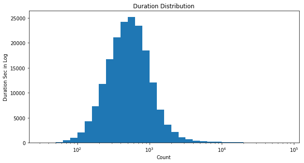

```python
# The first variable for exploration is the duration
plt.figure(figsize=[10,5])
bins= 10**np.arange(1+0.5,5,0.1)
plt.hist(data=df_clean,x='duration_sec',bins=bins,color=color)
x_y_t('Count','Duration Sec in Log','Duration Distribution')
plt.xscale('log')
```

```python
df_clean['duration_sec'].describe()
```

```
count    183412.000000
mean        726.078435
std        1794.389780
min          61.000000
25%         325.000000
50%         514.000000
75%         796.000000
max       85444.000000
Name: duration_sec, dtype: float64
```

### The shortest trip was 61 seconds and the longest trip was 85444 seconds. The duration is normally distributed when plotted using logs¶

### How is the Gender distributed

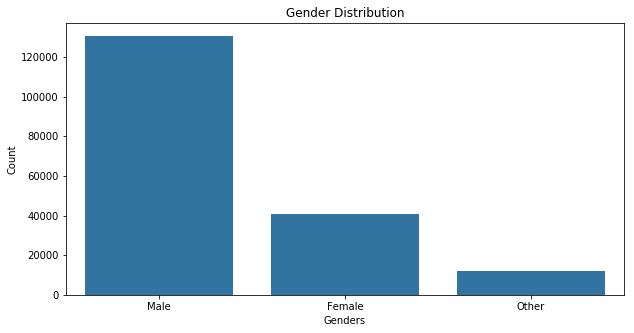

```python
#Member gender viz
plt.figure(figsize=[10,5])
sb.countplot(data=df_clean,x='member_gender',color=color,order=df_clean['member_gender'].value_counts().index)
x_y_t('Genders','Count','Gender Distribution')
```

[output not shown]

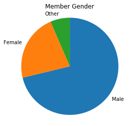

```python
#create a pie chart to better illustrate the difference in memmber gender as relative frequency
sorted_counts=df_clean['member_gender'].value_counts()
my_labels=['Male',"Female",'Other']
plt.pie(sorted_counts,labels=my_labels,startangle=90,counterclock=False)
plt.axis('square')
plt.title('Member Gender')
```

## Gender Distribution

> > Most members in the dataset are Male, with a huge difference from the female

## Age Distribution

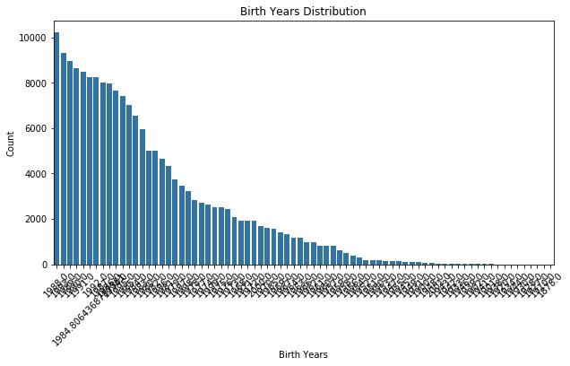

```python
#Member birth year viz
plt.figure(figsize=[10,5])
sb.countplot(data=df_clean,x='member_birth_year',color=color,order=df_clean['member_birth_year'].value_counts().index)
x_y_t('Birth Years','Count','Birth Years Distribution')
plt.xticks(rotation=45)
```

### The members birth year visualization doesnt clearly show the years with most members

#### Will therefore create a new column Age , create a histogram to show the age cap with most members

```python
#Create a new column Age to visua;ize the age with most members
df_clean['member_birth_year']=df_clean['member_birth_year'].astype(int)
df_clean['Age']=2022-df_clean['member_birth_year']
```

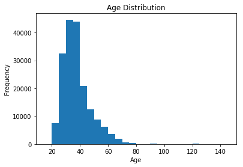

```python
#visualize the Age distribution
bins=np.arange(15,df_clean['Age'].max()+5,5)
plt.hist(data=df_clean,x='Age',color=color,bins=bins)
x_y_t('Age','Frequency','Age Distribution')
```

### Age variable is right skewed with the high numbers between the age of 25 and 40 years. The highest being between 30 and 40.

### Which stations are popular?

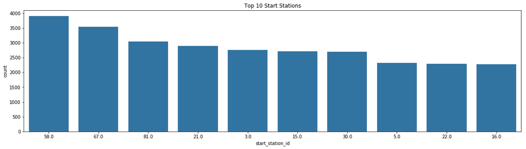

```python
#the first 10 start station with the most counts
plt.figure(figsize=[20,5])
x_y_t('Station ID','Frequency','Top 10 Start Stations')
sb.countplot(data=df_clean,x='start_station_id',color=color,order=df_clean['start_station_id'].value_counts().index[0:10])
```

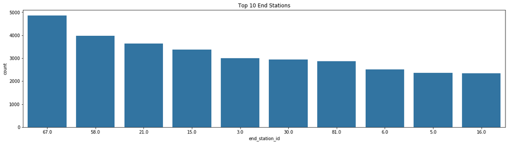

```python
#the first 10 end station with the most counts
plt.figure(figsize=[20,5])
x_y_t('Station ID','Frequency','Top 10 End Stations')
sb.countplot(data=df_clean,x='end_station_id',color=color,order=df_clean['end_station_id'].value_counts().index[0:10])
```

### Most of the stations in the top start stations are also seen in the top end stations. For instance station 58, 67,81,21 etc

```python
#check the start station name of the station id 58
df_clean.loc[df_clean['start_station_id']==58]
```

[output not shown]

3904 rows × 17 columns

```python
#check the start station name of the station id 67
df_clean.loc[df_clean['start_station_id']==67]
```

[output not shown]

3544 rows × 17 columns

```python
#check the start station name of the station id 81
df_clean.loc[df_clean['start_station_id']==81]
```

[output not shown]

3052 rows × 17 columns

```python
#check the start station name of the station id 21
df_clean.loc[df_clean['start_station_id']==21]
```

[output not shown]

2895 rows × 17 columns

#### The most common station are station : Montgomery St BART Station (Market St at 2nd St),San Francisco Caltrain Station 2,Market St at 10th St ,Berry St at 4th St .

### Do most users share their bike trips?

```
No     166053
Yes     17359
Name: bike_share_for_all_trip, dtype: int64
```

```
Text(0.5,1,'Bike sharing for Trips')
```

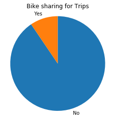

```python
#create a pie chart for the bike sharing response
sorted_counts=df_clean['bike_share_for_all_trip'].value_counts()
my_labels=df_clean['bike_share_for_all_trip'].unique()
plt.pie(sorted_counts,labels=my_labels,startangle=90,counterclock=False)
plt.axis('square')

print(df_clean['bike_share_for_all_trip'].value_counts())
plt.title("Bike sharing for Trips")
```

#### Most of the users didnt share the bike trip

### Days of the Week distribution in start and end time.

```python
def count_week(data,x,color,order):
    sb.countplot(data=data,x=x,color=color,order=order)
order=['Monday','Tuesday',"Wednesday",'Thursday','Friday','Sartuday','Sunday']
```

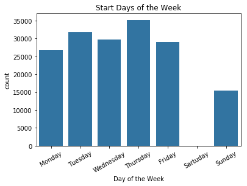

```python
#create a new column for the day of week start time.and end time
df_clean['StartDay_of_week']= df_clean['start_time'].dt.day_name()
df_clean['EndDay_of_week']= df_clean['end_time'].dt.day_name()
count_week(df_clean,'StartDay_of_week',color,order)
plt.xticks(rotation=30)
x_y_t('Day of the Week','count','Start Days of the Week')
```

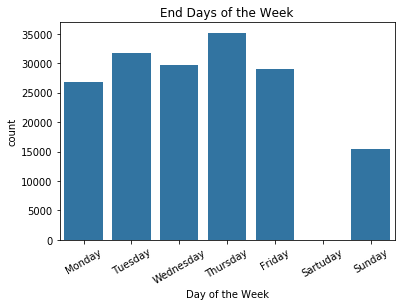

```python
count_week(df_clean,'EndDay_of_week',color,order)
x_y_t('Day of the Week','count','End Days of the Week')
plt.xticks(rotation=30)
```

```python
#Counts of end day of the week
df_clean['StartDay_of_week'].value_counts()
```

```
Thursday     35197
Tuesday      31813
Wednesday    29641
Friday       28981
Monday       26852
Sunday       15523
Saturday     15405
Name: StartDay_of_week, dtype: int64
```

```python
#counts of each day of the weeek
df_clean['EndDay_of_week'].value_counts()
```

```
Thursday     35185
Tuesday      31820
Wednesday    29631
Friday       28981
Monday       26859
Sunday       15523
Saturday     15413
Name: EndDay_of_week, dtype: int64
```

### Discuss the distribution(s) of your variable(s) of interest. Were there any unusual points? Did you need to perform any transformations?

> > Most of the members in the dataset are Male and the membership type with more members is the subsriber. Most users dont share bike trips The age between 25- 40 has more members , the numbers then decrease to 80 yrs with outliers such as 110 years and 120yrs The Day with highest number of bikes rented is thursday, followed closely by tuesday. The Day with the least number of biked rented is Sartuday and Sunday

### Of the features you investigated, were there any unusual distributions? Did you perform any operations on the data to tidy, adjust, or change the form of the data? If so, why did you do this?

> The outliers in the Age distribution are ignored.

## Bivariate Exploration

### What is the relationship between the user type and gender

```python
def count_viz(data,x,hue):
    sb.countplot(data=data,x=x,hue=hue)
```

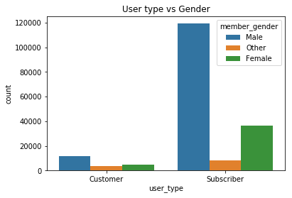

```python
# the relationship between membership type and member gender
x_y_t('User type','Count','User type vs Gender')
count_viz(df_clean,'user_type','member_gender')
```

#### The relationship is not very clear since most of the users are male and subscribers.

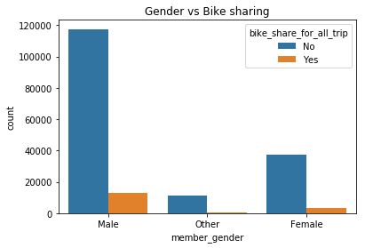

```python
#The relationship between member gender and bike sharing
x_y_t('Gender','count','Gender vs Bike sharing')
count_viz(df_clean,'member_gender','bike_share_for_all_trip')
```

#### Most users dont share the bike trips, this visualization doesnt show any relationship between bike shares and gender of the users

### Gender/User type and Age relationship

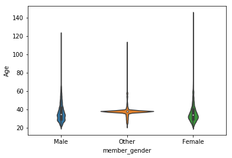

```python
#The relationship between Age and member gender
sb.violinplot(data=df_clean,x='member_gender',y='Age')
```

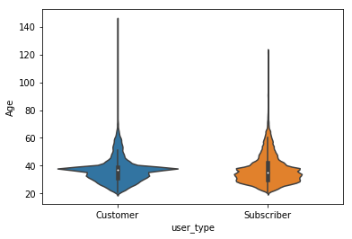

```python
#relationship between Age and user type
sb.violinplot(data=df_clean,x='user_type',y='Age')
```

#### Age is similarly distributed for Male and Female without considering the outliers

##### Most of the customers are ages 40, while most of the subcribers are almost evenly distributed between ages 30 and 40.

## Days of the week vs Membership type

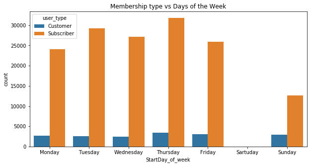

```python
plt.figure(figsize=[10,5])
plt.title('Membership type vs Days of the Week')
sb.countplot(data=df_clean,x='StartDay_of_week',hue='user_type',order=order)
```

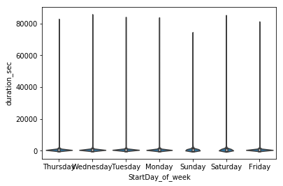

```python
sb.violinplot(data=df_clean,x='StartDay_of_week',y='duration_sec',color=color)
```

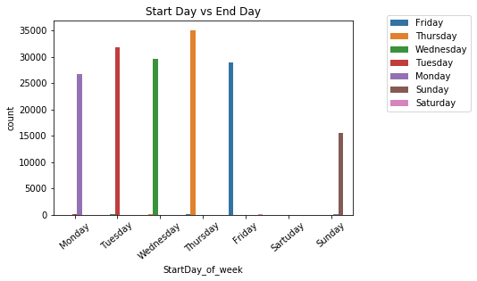

```python
plt.title("Start Day vs End Day")
plt.xlabel("Start Day")
sb.countplot(data=df_clean,x='StartDay_of_week',hue='EndDay_of_week',order=order)
plt.xticks(rotation=40)
plt.legend(bbox_to_anchor=(1.1, 1.05))
```

### Talk about some of the relationships you observed in this part of the investigation. How did the feature(s) of interest vary with other features in the dataset?

> Age is similarly distributed for Male and Female without considering the outliers Most of the customers are ages 40, while most of the subcribers are almost evenly distributed between ages 30 and 40.

> Most users dont share the bike trips, the visualization doesnt show any relationship between bike shares and gender of the users

### Did you observe any interesting relationships between the other features (not the main feature(s) of interest)?

> I did not discover any other interesting feature in the dataset

## Multivariate Exploration

> Create plots of three or more variables to investigate your data even further. Make sure that your investigations are justified, and follow from your work in the previous sections.

### Age, Gender and User type

```python
def box_plot(data,x,y,hue):
    plt.figure(figsize=[10,8])
    sb.boxplot(data=data,x=x,y=y,hue=hue)
    plt.legend(loc=0,bbox_to_anchor=[1,0.5])
```

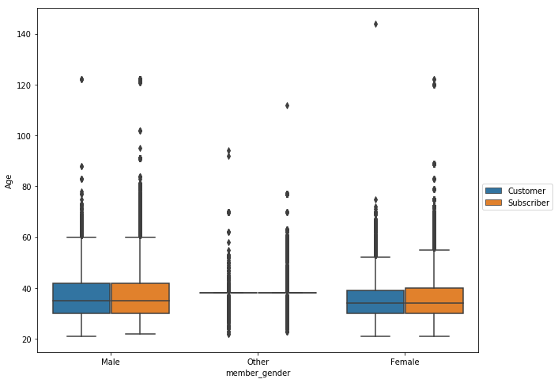

```python
#boxplot for member gender, age and user type
box_plot(df_clean,'member_gender','Age','user_type')
```

### Age , user type and Bike sharing

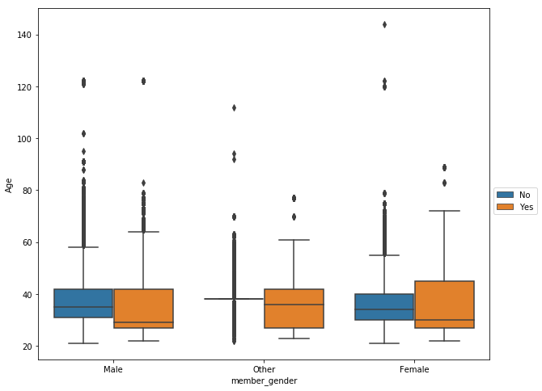

```python
box_plot(df_clean,'member_gender','Age','bike_share_for_all_trip')
```

### The age distribution for those not sharing bike trips is positively skewed (Male and female)

#### other gender, no bike share trips is negatively skewed

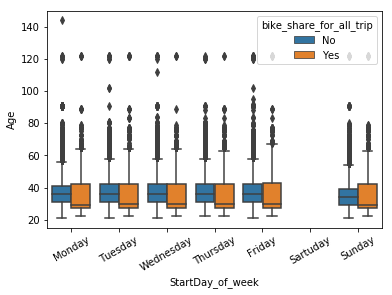

```python
sb.boxplot(data=df_clean,x='StartDay_of_week',y='Age',hue='bike_share_for_all_trip',order=order)
plt.xticks(rotation=30)
```

#### Through out the week the Age distribution for those sharing bike trips is positively skewed

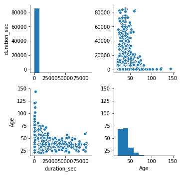

```python
#create  a new dataframe with few focus columns
df_viz= df_clean[['duration_sec','Age','user_type','bike_share_for_all_trip','StartDay_of_week','member_gender']].copy()
sb.pairplot(df_viz)
#a pairplot of the new dataframe
```

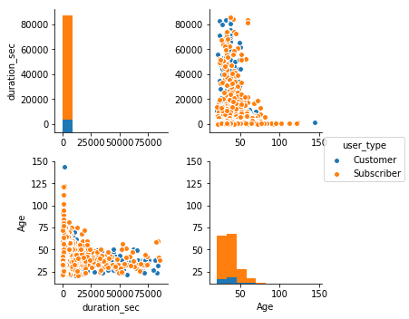

```python
sb.pairplot(df_viz,hue='user_type')
plt.show()
#pairplot with user type as hue to see how different user types are relating to each varible
```

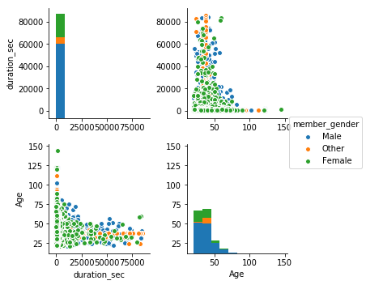

```python
sb.pairplot(df_viz,hue='member_gender')
#show how genders are relating to other variables
```

### Were there any interesting or surprising interactions between features?

> Female have shorter trips older people have short bike trips

## Conclusions

> Age : Age is skewed with high number between 25 and 40 years. There are some outliers in this variable,120years.

> user-type : Subscirbers are more than customers

> Gender : Male bike renters are more as compared to female.

> Bike share: There are few people sharing bike trips

> Days : thursday is the day of the week with the highest number of start time and end time

> Stations : the most common station are station : Montgomery St BART Station (Market St at 2nd St),San Francisco Caltrain Station 2,Market St at 10th St ,Berry St at 4th St .

```python
#save the updated dataframe to a new csv file
df_clean.to_csv("Clean_data_bikes_share.csv")
```